# Solution to Homework 4

STATS/DATASCI 531

**Question 4.1**.

**Part A**.

Given the AR2 model
$$\begin{align*}
X_{n}=1.5X_{n-1}-0.8X_{n-2}+\epsilon_{n},
\end{align*}$$
we have
$$\begin{align*}
\epsilon_{n}=X_{n}-1.5X_{n-1}+0.8X_{n-2}.
\end{align*}$$
By definition, the autocovariance of the white noise process $\{\epsilon_n\}$ is $\gamma_\epsilon(h) = \sigma^2$ for $h=0$ and $\gamma_\epsilon(h) = 0$ otherwise. Thus the spectrum of the white noise is
$$\lambda_\epsilon(\omega) = \sum_{h=-\infty}^\infty \gamma_\epsilon(h) e^{-i\omega h} = \sigma^2$$
for all $\omega$. Now we observe that the ACF for $\left\{\epsilon_{n}\right\}$ can be written as
$$\begin{split}
\gamma_{\epsilon}\left(h\right)&=\mathrm{Cov}\left(\epsilon_{n+h},\epsilon_{n}\right)\\
&=\mathrm{Cov}\left(X_{n+h}-1.5X_{n+h-1}+0.8X_{n+h-2},X_{n}-1.5X_{n-1}+0.8X_{n-2}\right)\\
&=(1+1.5^2+0.8^2)\gamma_{X}\left(h\right)+(-1.5-1.5\times0.8)\left[\gamma_{X}\left(h+1\right)+\gamma_{X}\left(h-1\right)\right]+0.8\left[\gamma_{X}\left(h+2\right)+\gamma_{X}\left(h-2\right)\right].
\end{split}$$
Thus we see that
$$\begin{split}
\lambda_\epsilon(\omega) &= \sum_{h=-\infty}^\infty \gamma_\epsilon(h) e^{-i\omega h}\\
&= \sum_{h=-\infty}^\infty \left\{ 3.89 \gamma_X(h) - 2.7 [\gamma_X(h+1)+\gamma_X(h-1)] + 0.8[\gamma_X(h+2)+\gamma_X(h-2)] \right\} e^{-i\omega h}.
\end{split}$$
Note that
$$\begin{split}
\sum_{h=-\infty}^\infty \gamma_X(h+1)e^{-i\omega h} &= \sum_{h=\infty}^\infty \gamma_X(h+1) e^{-i\omega (h+1)} e^{i\omega} \\
&= e^{i\omega} \sum_{h'=-\infty}^\infty \gamma_X(h') e^{-i\omega h'}\\
&= e^{i\omega} \lambda_X(\omega)
\end{split}$$

where we used the change of variable $h' = h+1$. Similarly, we have

$$\begin{align*}
\sum_{h=-\infty}^\infty \gamma_X(h-1)e^{-i\omega h} = e^{-i\omega} \lambda_X(\omega), \qquad \sum_{h=-\infty}^\infty \gamma_X(h+2)e^{-i\omega h} = e^{2i\omega} \lambda_X(\omega), \qquad \sum_{h=-\infty}^\infty \gamma_X(h-2)e^{-i\omega h} = e^{-2i\omega} \lambda_X(\omega).
\end{align*}$$

It follows that
$$\begin{align*}
\sigma^2 = \lambda_\epsilon(\omega) = 3.89 \lambda_X(\omega) - 2.7 (e^{i\omega} + e^{-i\omega}) \lambda_X(\omega) + 0.8 (e^{2i\omega} + e^{-2i\omega})\lambda_X(\omega).
\end{align*}$$
Therefore,
$$\begin{align*}
\lambda_{X}(\omega)=\frac{\sigma^{2}}{3.89-5.4\cos(\omega)+1.6\cos(2\omega)}.
\end{align*}$$

The plot of the spectral density and autocovariance are given as follows. Note that $\omega = 2\pi f$, where $f$ denotes the frequency in cycles per unit time and $\omega$ measures radians per unit time.

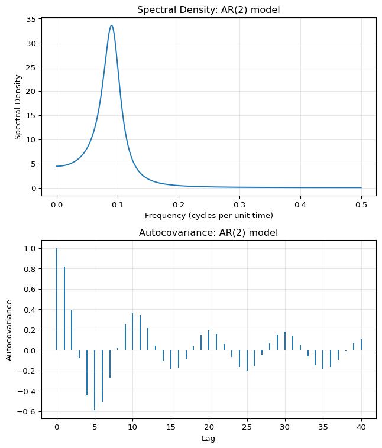

**Part B**.

Given the MA2 model

$$\begin{align*}
X_{n}=\epsilon_{n-2}+\epsilon_{n-1}+\epsilon_{n}
\end{align*}$$
with $\mathrm{Var}\left(\epsilon_{n}\right)=\sigma^{2}$, we start by writing the ACF
$$\begin{eqnarray}
\gamma\left(0\right)&=&\mathrm{Cov}\left(X_{n},X_{n}\right)=3\sigma^{2}\\
\gamma\left(1\right)&=&\gamma\left(-1\right)=\mathrm{Cov}\left(X_{n},X_{n-1}\right)=2\sigma^{2}\\
\gamma\left(2\right)&=&\gamma\left(-2\right)=\mathrm{Cov}\left(X_{n},X_{n-2}\right)=\sigma^{2}\\
\gamma\left(h\right)&=&0\;\forall|h|\geq3.
\end{eqnarray}$$
So we have
$$\begin{split}
\lambda(\omega)&=\sum_{h=-\infty}^\infty \gamma\left(h\right)e^{- i\omega h}\\
&=\sum_{h=-2}^{2}\gamma(h)e^{-i\omega h}\\
&=\gamma(0)+2 \gamma(1)\cos(\omega)+2\gamma(2)\cos(2\omega)\\
&=\sigma^{2}\left[3+4\cos(\omega)+2\cos(2\omega)\right]
\end{split}$$

The plot of the spectral density and autocovariance are given as follows:

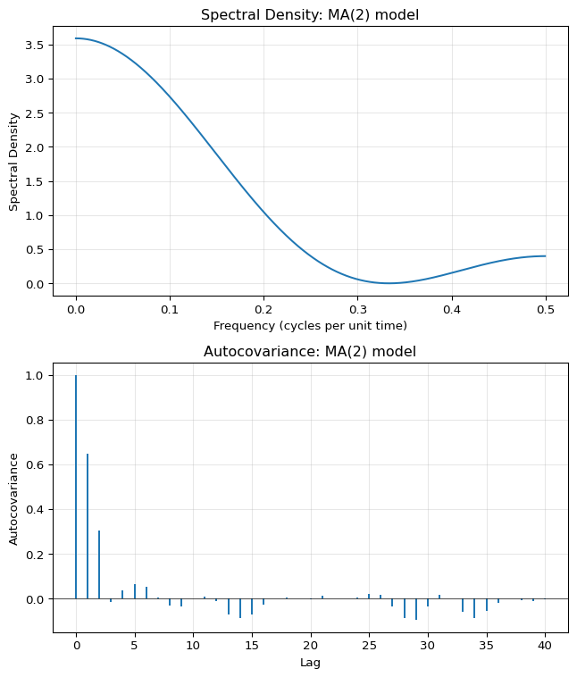

**Part C**.

**Question 4.2**.  
We first read in the data from the source. We seek to find out the relationship between time and number. We now make a time plot of the data to explore.

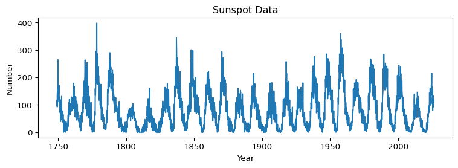

From the plot, we see that there is a periodic behavior, with regularly spaced peaks. The time interval between these peaks are about 11 years. This is as expected from reading the NASA website [1].

Now we take a look at the inconsistent spectral density estimate provided by the raw periodogram:

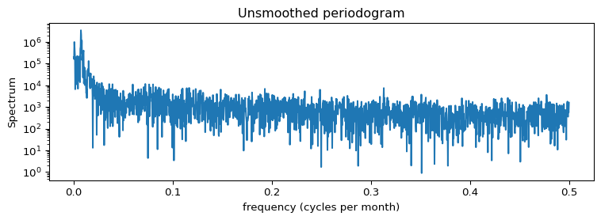

This obtains a maximum at 0.00752 $\mathrm{month}^{-1}$, which corresponds to a period of 11.1 years.

We compare with using repeated rectangular smoothing windows to obtain a non-parametrically smoothed periodogram.

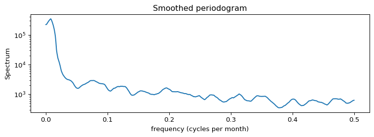

We now determine the dominant frequency.

We see that the dominant frequency is 0.00782 $\mathrm{month}^{-1}$, which corresponds to a period of 10.7 years.

Now we use parametric method to estimate the spectral density.

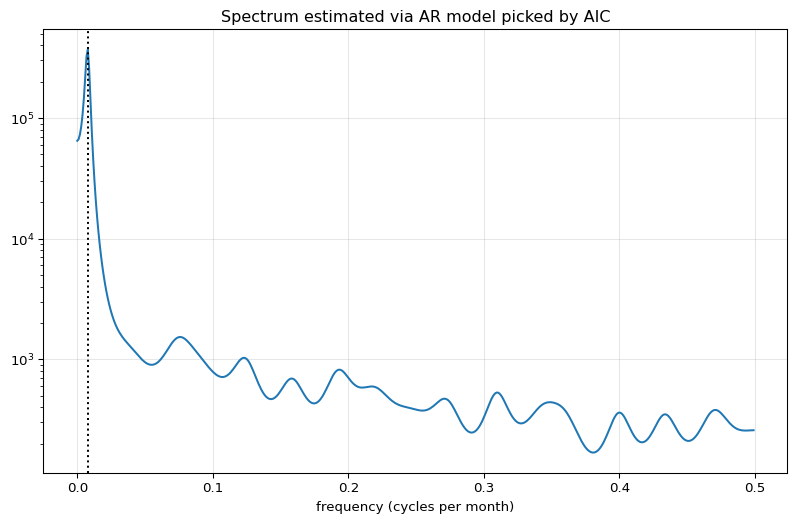

We find that the dominant frequency is 0.00781 $\mathrm{month}^{-1}$, which corresponds to a period of 10.7 years.

We see that the parametric approach gives a sharper peak estimate, which may be appropriate in this siutation.

These two estimates are somewhat similar to each other, to the result from the raw periodogram, and to the 11 year period discussed by [1]. In the absence of a full stochastic model for the sunspots, it is hard to say which of these is most trustworthy.

### Sources

Parts of this solution are adapted from a previous homework submission by Xiang Gao. This is a vague attribution, perhaps appropriate here since it is not necessary to evalutate individual contributions. For homework submissions, a generic attribution like this is not appropriate. One should help the grader by being more precise about which parts of the code and/or explanation are derived from the source.

## References

1.

National Aeronautics and Space Administration (2017). [The sunspot cycle](https://solarscience.msfc.nasa.gov/SunspotCycle.shtml).